# Prosper Loan Data Exploration

### *by Osaze Agho*

- Introduction
- Preliminary Wrangling
- Exploratory Data Analysis (EDA)
- Univariate Exploration
- Bivariate Exploration
- Miltivariate Exploration
- Conclusions

## Introduction

Prosper is America's first peer-to-peer lending marketplace and was founded in 2005. Prosper connects borrowers with willing investors, and takes a small fee. Peer-to-peer lending often attracts borrowers who are unable to qualify for traditional bank loans.

I conducted an Explanatory Data Analysis (EDA) on the loan data set obtained from Propser. The data set contains 113,937 loans with 81 variables on each loan, including loan amount, borrower rate (or interest rate), current loan status, borrower income, and many others. The data set covers the time period 2005 to 2014, the first 9 years of the business.

## Preliminary Wrangling

```python
# import all packages and set plots to be embedded inline
import numpy as np
import pandas as pd
import matplotlib.pyplot as plt
import seaborn as sb

%matplotlib inline

# Ignore warning messages
import warnings
warnings.filterwarnings('ignore')
```

```python
# load the dataset into a pandas dataframe
df_loan = pd.read_csv('prosperLoanData.csv')
df_loan.head()
```

|  | ListingKey | ListingNumber | ListingCreationDate | CreditGrade | Term | LoanStatus | ClosedDate | BorrowerAPR | BorrowerRate | LenderYield | ... | LP_ServiceFees | LP_CollectionFees | LP_GrossPrincipalLoss | LP_NetPrincipalLoss | LP_NonPrincipalRecoverypayments | PercentFunded | Recommendations | InvestmentFromFriendsCount | InvestmentFromFriendsAmount | Investors |
| --- | --- | --- | --- | --- | --- | --- | --- | --- | --- | --- | --- | --- | --- | --- | --- | --- | --- | --- | --- | --- | --- |
| 0 | 1021339766868145413AB3B | 193129 | 2007-08-26 19:09:29.263000000 | C | 36 | Completed | 2009-08-14 00:00:00 | 0.16516 | 0.1580 | 0.1380 | ... | -133.18 | 0.0 | 0.0 | 0.0 | 0.0 | 1.0 | 0 | 0 | 0.0 | 258 |
| 1 | 10273602499503308B223C1 | 1209647 | 2014-02-27 08:28:07.900000000 | NaN | 36 | Current | NaN | 0.12016 | 0.0920 | 0.0820 | ... | 0.00 | 0.0 | 0.0 | 0.0 | 0.0 | 1.0 | 0 | 0 | 0.0 | 1 |
| 2 | 0EE9337825851032864889A | 81716 | 2007-01-05 15:00:47.090000000 | HR | 36 | Completed | 2009-12-17 00:00:00 | 0.28269 | 0.2750 | 0.2400 | ... | -24.20 | 0.0 | 0.0 | 0.0 | 0.0 | 1.0 | 0 | 0 | 0.0 | 41 |
| 3 | 0EF5356002482715299901A | 658116 | 2012-10-22 11:02:35.010000000 | NaN | 36 | Current | NaN | 0.12528 | 0.0974 | 0.0874 | ... | -108.01 | 0.0 | 0.0 | 0.0 | 0.0 | 1.0 | 0 | 0 | 0.0 | 158 |
| 4 | 0F023589499656230C5E3E2 | 909464 | 2013-09-14 18:38:39.097000000 | NaN | 36 | Current | NaN | 0.24614 | 0.2085 | 0.1985 | ... | -60.27 | 0.0 | 0.0 | 0.0 | 0.0 | 1.0 | 0 | 0 | 0.0 | 20 |

5 rows × 81 columns

```python
# explore shape of dataset
df_loan.shape
```

```
(113937, 81)
```

The result shows us that this dataset has:

- Total rows - 113937
- Total columns - 81

```python
# explore by showing a concise summary of the dataframe
df_loan.info()
```

```
<class 'pandas.core.frame.DataFrame'>
RangeIndex: 113937 entries, 0 to 113936
Data columns (total 81 columns):
 #   Column                               Non-Null Count   Dtype
---  ------                               --------------   -----
 0   ListingKey                           113937 non-null  object
 1   ListingNumber                        113937 non-null  int64
 2   ListingCreationDate                  113937 non-null  object
 3   CreditGrade                          28953 non-null   object
 4   Term                                 113937 non-null  int64
 5   LoanStatus                           113937 non-null  object
 6   ClosedDate                           55089 non-null   object
 7   BorrowerAPR                          113912 non-null  float64
 8   BorrowerRate                         113937 non-null  float64
 9   LenderYield                          113937 non-null  float64
```

[output cut: 73 more lines]

```python
# define variables of interest to analysis
relevant = ['ListingKey', 'ListingCreationDate', 'LoanStatus', 'Term', 'ProsperScore', 'ProsperRating (Alpha)',
            'BorrowerRate', 'ListingCategory (numeric)', 'LoanOriginalAmount', 'Occupation',
            'IsBorrowerHomeowner','DebtToIncomeRatio', 'IncomeRange', 'BorrowerState']
```

```python
# create new dataframe to select variables relevant for project
df_relevant = df_loan[relevant]
df_relevant.head()
```

|  | ListingKey | ListingCreationDate | LoanStatus | Term | ProsperScore | ProsperRating (Alpha) | BorrowerRate | ListingCategory (numeric) | LoanOriginalAmount | Occupation | IsBorrowerHomeowner | DebtToIncomeRatio | IncomeRange | BorrowerState |
| --- | --- | --- | --- | --- | --- | --- | --- | --- | --- | --- | --- | --- | --- | --- |
| 0 | 1021339766868145413AB3B | 2007-08-26 19:09:29.263000000 | Completed | 36 | NaN | NaN | 0.1580 | 0 | 9425 | Other | True | 0.17 | $25,000-49,999 | CO |
| 1 | 10273602499503308B223C1 | 2014-02-27 08:28:07.900000000 | Current | 36 | 7.0 | A | 0.0920 | 2 | 10000 | Professional | False | 0.18 | $50,000-74,999 | CO |
| 2 | 0EE9337825851032864889A | 2007-01-05 15:00:47.090000000 | Completed | 36 | NaN | NaN | 0.2750 | 0 | 3001 | Other | False | 0.06 | Not displayed | GA |
| 3 | 0EF5356002482715299901A | 2012-10-22 11:02:35.010000000 | Current | 36 | 9.0 | A | 0.0974 | 16 | 10000 | Skilled Labor | True | 0.15 | $25,000-49,999 | GA |
| 4 | 0F023589499656230C5E3E2 | 2013-09-14 18:38:39.097000000 | Current | 36 | 4.0 | D | 0.2085 | 2 | 15000 | Executive | True | 0.26 | $100,000+ | MN |

```python
# concise summary of dataframe
df_relevant.info()
```

```
<class 'pandas.core.frame.DataFrame'>
RangeIndex: 113937 entries, 0 to 113936
Data columns (total 14 columns):
 #   Column                     Non-Null Count   Dtype
---  ------                     --------------   -----
 0   ListingKey                 113937 non-null  object
 1   ListingCreationDate        113937 non-null  object
 2   LoanStatus                 113937 non-null  object
 3   Term                       113937 non-null  int64
 4   ProsperScore               84853 non-null   float64
 5   ProsperRating (Alpha)      84853 non-null   object
 6   BorrowerRate               113937 non-null  float64
 7   ListingCategory (numeric)  113937 non-null  int64
 8   LoanOriginalAmount         113937 non-null  int64
 9   Occupation                 110349 non-null  object
 10  IsBorrowerHomeowner        113937 non-null  bool
 11  DebtToIncomeRatio          105383 non-null  float64
 12  IncomeRange                113937 non-null  object
 13  BorrowerState              108422 non-null  object
dtypes: bool(1), float64(3), int64(3), object(7)
memory usage: 11.4+ MB
```

```python
# check for duplicates
df_relevant.duplicated().sum()
```

```
0
```

### Quality Issues

- Missing data in `ProsperRating (Alpha)`,`ProsperScore`, `BorrowerAPR`, `Occupation`, `DebtToIncomeRatio`, `BorrowerState`
- Erroneous Datatype (`ListingCreationDate` in string instead of datetime format)
- Non-descriptive values, datatype, and column name for `ListingCategory (numeric)`

### Tidiness Issue

- Date and Time stamp in `ListingCreationDate` not suitable for analysis

### Cleaning Data

##### Issue #1:

- Missing data in `ProsperRating (Alpha)`,`ProsperScore`, `BorrowerAPR`, `Occupation`, `DebtToIncomeRatio`, `BorrowerState`

##### Define

For this analysis, [`ProsperRating`](https://www.prosper.com/invest/how-to-invest/prosper-ratings/?mod=article_inline) is a very important variable as it is a rating assigned to each Borrower Loan at the time it is posted for bids on the prosper platform. This rating is calculated using a number of elements, especially the `ProsperScore`, and `Credit Score` from the consumer credit bureau.

Loan Listings also include the Prosper Rating, which is a letter grade that indicates the level of risk associated with the listing. Hence, for this analysis, we cannot have null values in the `ProsperRating` column.

Due to the missing `ProsperRating` values, data cleaning will start with the following steps:

- Change column name from `ProsperRating (Alpha)` to `ProsperRating`
- Select non-null values in the `ProsperRating` column
- Drop the remaining null values in `ProsperScore` and `BorrowerState` columns
- fill missing values in `DebtToIncomeRatio` with the mean
- fill missing values in `Occupation` with "Unknown"

##### Code

```python
# Remove "(Alpha)" from the column name ListingCategory (numeric)
df_relevant = df_relevant.rename(columns={'ProsperRating (Alpha)': 'ProsperRating'})
```

```python
# select only observations with values in the `ProsperScore` column and dispay random sample from dataset
df_relevant = df_relevant[df_relevant.ProsperRating.notnull()]
```

```python
# check to see variables with missing values
df_relevant[['ProsperScore', 'BorrowerState', 'Occupation', 'DebtToIncomeRatio']].isnull().sum()
```

```
ProsperScore            0
BorrowerState           0
Occupation           1333
DebtToIncomeRatio    7296
dtype: int64
```

It can be seen that selling the rows that had non-null values in `ProsperRating` dropped the null values in `ProsperScore`, `BorrowerAPR`, and `BorrowerState`.

```python
# fill missing values in `DebtToIncomeRatio` with mean
df_relevant['DebtToIncomeRatio'] = df_relevant['DebtToIncomeRatio'].fillna(df_relevant['DebtToIncomeRatio'].mean())
```

```python
# fill missing values in `Occupation` with "Unknown"
df_relevant['Occupation'] = df_relevant['Occupation'].fillna('Unknown')
```

##### Test

```python
# confirm no missing values in all columns
df_relevant.isnull().sum().values
```

```
array([0, 0, 0, 0, 0, 0, 0, 0, 0, 0, 0, 0, 0, 0], dtype=int64)
```

##### Issue #2:

- Erroneous Datatype (`ListingCreationDate` in string instead of datetime format)

##### Define

- Convert `ListingCreationDate` datatype from string to datetime

##### Code

```python
# convert string to datetime
df_relevant['ListingCreationDate'] = pd.to_datetime(df_relevant['ListingCreationDate'])
```

##### Test

```python
# confirm changed datatype
df_relevant['ListingCreationDate'].info()
```

```
<class 'pandas.core.series.Series'>
Int64Index: 84853 entries, 1 to 113936
Series name: ListingCreationDate
Non-Null Count  Dtype
--------------  -----
84853 non-null  datetime64[ns]
dtypes: datetime64[ns](1)
memory usage: 1.3 MB
```

##### Issue #3:

- Non-descriptive values, datatype, and column name for `ListingCategory (numeric)`

##### Define

- Change column name from `ListingCategory (numeric)` to `ListingCategory`
- Use the categories as categorical values instead of numerical values
- Convert `ListingCategory (numeric)` datatype from int64 to string

##### Code

```python
# Remove "(numeric)" from the column name ListingCategory (numeric)
df_relevant = df_relevant.rename(columns={'ListingCategory (numeric)': 'ListingCategory'})
```

```python
# create dictionary with `ListingCategories` numeric values as 'keys' and their non-numeric values as 'values'
list_dict = {0 : 'Not Available', 1 : 'Debt Consolidation', 2 : 'Home Improvement', 3: 'Business',
             4 : 'Personal Loan', 5 : 'Student Use', 6 : 'Auto', 7 : 'Other', 8 : 'Baby&Adoption',
             9 : 'Boat', 10 : 'Cosmetic Procedure', 11 : 'Engagement Ring', 12 : 'Green Loans',
             13 : 'Household Expenses', 14 : 'Large Purchases', 15 : 'Medical/Dental', 16 : 'Motorcycle',
             17 : 'RV', 18 : 'Taxes', 19 : 'Vacation', 20 : 'Wedding Loans'}

# substitute each key in the dictionary with the key
df_relevant['ListingCategory'] = df_relevant['ListingCategory'].map(list_dict)
```

```python
# reset index (index starts from 0)
df_relevant.reset_index(drop = True, inplace = True)
```

##### Test

```python
# check to see the categorical descriptions of the `ListingCategories` have replaced the numerical
print(df_relevant['ListingCategory'].dtype)
df_relevant['ListingCategory'].values
```

```
object
```

```
array(['Home Improvement', 'Motorcycle', 'Home Improvement', ...,
       'Debt Consolidation', 'Home Improvement', 'Debt Consolidation'],
      dtype=object)
```

#### Issue #4:

- Date and Time stamp in `ListingCreationDate` not suitable for analysis

#### Define

- In this project, the `Year` and `Month` values in the `ListingCreationDate` column are more suitable for analysis individually and will seperated in new columns. The `ListingCreationDate` column will be dropped.

##### Code

```python
# extract year from `ListingCreationDate` column
df_relevant['listing_year'] = df_relevant['ListingCreationDate'].dt.year

# extract month from `ListingCreationDate` column
df_relevant['listing_month'] = df_relevant['ListingCreationDate'].dt.month


# # convert new `listing_date` column datatype from string to datetime
# df_relevant['listing_date'] = pd.to_datetime(df_relevant['listing_date'])

# drop `ListingCreationDate`
df_relevant.drop(['ListingCreationDate'], axis = 1, inplace = True)
```

```python
# change the numerical naming of months in `month` column to non-numerical

# First, convert `month` column from int64 to str
df_relevant.listing_month = df_relevant.listing_month.astype(str)

# replace the numerical values with non-numerical
df_relevant.listing_month.replace(['1','2','3','4','5','6','7','8','9','10','11','12'],
                         ['Jan','Feb','Mar','Apr','May','Jun','Jul','Aug','Sep','Oct','Nov','Dec'], inplace = True)
```

##### Test

```python
# display months
df_relevant.listing_month.values
```

```
array(['Feb', 'Oct', 'Sep', ..., 'Dec', 'Nov', 'Jan'], dtype=object)
```

## Exploratory Data Analysis (EDA)

### Main feature(s) of interest in dataset

In this analysis, the main variables of interest are Loan Status and interest rate

> I am most interested in exploring:
> - *What factors affect the borrower's interest rates*
> - *The relationships among multiple variables using summary statistics and data visualizations*

### Features in the dataset to support the investigation into the main feature(s) of interest

> There are a lot of variables to explore, but for this analysis, my focus will mainly be on 13 variables from the original data set and the 2 newly created variables (listing_year, listing_month):
> - **`ListingKey`** - Unique key for each listing, same value as the 'key' used in the listing object in the API.
> - **`Listing_year`** - The year the listing was created.
> - **`Listing_month`** - The month the listing was created.
> - **`LoanStatus`** - The current status of the loan: Cancelled, Chargedoff, Completed, Current, Defaulted, FinalPaymentInProgress, PastDue. The PastDue status will be accompanied by a delinquency bucket.
> - **`Term`** - The length of the loan expressed in months.
> - **`ProsperScore`** - A custom risk score built using historical Prosper data. The score ranges from 1-11, with 11 being the best, or lowest risk score. Applicable for loans originated after July 2009.
> - **`ProsperRating`** - Prosper Ratings allow investors to consider a loan's level of risk because the rating represents an estimated average annualized loss rate range. The Prosper Rating assigned at the time the listing was created between AA - HR, with AA being the best, or lowest risk rating. Applicable for loans originated after July 2009.
> - **`BorrowerRate`** - The Borrower's interest rate for this loan.
> - **`ListingCategory`** - The category of the listing that the borrower selected when posting their listing: (*Not Available, Debt Consolidation, Home Improvement, Business, Personal Loan, Student Use, Auto, Other, Baby&Adoption, Boat, Cosmetic Procedure, Engagement Ring, Green Loans, Household Expenses, Large Purchases, Medical/Dental, Motorcycle, RV, Taxes, Vacation, Wedding Loans*)
> - **`LoanOriginalAmount`** - The origination amount of the loan.
> - **`BorrowerState`** - The two letter abbreviation of the state of the address of the borrower at the time the Listing was created.
> - **`Occupation`** - The Occupation selected by the Borrower at the time they created the listing.
> - **`IsBorrowerHomeowner`** - A Borrower will be classified as a homowner if they have a mortgage on their credit profile or provide documentation confirming they are a homeowner.
> - **`DebtToIncomeRatio`** - The debt to income ratio of the borrower at the time the credit profile was pulled. This value is Null if the debt to income ratio is not available. This value is capped at 10.01 (any debt to income ratio larger than 1000% will be returned as 1001%).
> - **`IncomeRange`** - The income range of the borrower at the time the listing was created.

The [data dictionary](https://docs.google.com/spreadsheets/d/1gDyi_L4UvIrLTEC6Wri5nbaMmkGmLQBk-Yx3z0XDEtI/edit#gid=0) describes the other variables in the original dataset not explored in this analysis

```python
# random sample of dataset
df_relevant.sample(5)
```

|  | ListingKey | LoanStatus | Term | ProsperScore | ProsperRating | BorrowerRate | ListingCategory | LoanOriginalAmount | Occupation | IsBorrowerHomeowner | DebtToIncomeRatio | IncomeRange | BorrowerState | listing_year | listing_month |
| --- | --- | --- | --- | --- | --- | --- | --- | --- | --- | --- | --- | --- | --- | --- | --- |
| 38370 | FC1E3603237065293E9C4CB | Current | 36 | 2.0 | E | 0.2800 | Debt Consolidation | 5000 | Laborer | False | 0.110000 | $25,000-49,999 | NY | 2014 | Feb |
| 50456 | 94CD35312225154731E12CB | Current | 36 | 1.0 | E | 0.3160 | Debt Consolidation | 3000 | Clerical | True | 0.660000 | $25,000-49,999 | TX | 2011 | Nov |
| 64421 | D1DE3572274161450F4A39E | Current | 60 | 8.0 | A | 0.1269 | Debt Consolidation | 22500 | Analyst | True | 0.160000 | $50,000-74,999 | NJ | 2013 | Mar |
| 75479 | D1B53567191551361E5CB3D | Current | 60 | 4.0 | C | 0.2262 | Debt Consolidation | 6000 | Clerical | True | 0.390000 | $1-24,999 | TN | 2013 | Jan |
| 66894 | 450834746013081249D39C3 | Completed | 36 | 10.0 | AA | 0.0705 | Debt Consolidation | 1700 | Skilled Labor | True | 0.258752 | $25,000-49,999 | WI | 2010 | Jan |

```python
# rearrange columns
df_relevant = df_relevant[['ListingKey', 'listing_year','listing_month', 'LoanStatus', 'ProsperScore', 'ProsperRating',
                           'BorrowerRate','Term', 'ListingCategory', 'LoanOriginalAmount', 'Occupation', 'IsBorrowerHomeowner',
                           'DebtToIncomeRatio', 'IncomeRange', 'BorrowerState']]
```

```python
# concise summary of the dataset
df_relevant.info()
```

```
<class 'pandas.core.frame.DataFrame'>
RangeIndex: 84853 entries, 0 to 84852
Data columns (total 15 columns):
 #   Column               Non-Null Count  Dtype
---  ------               --------------  -----
 0   ListingKey           84853 non-null  object
 1   listing_year         84853 non-null  int64
 2   listing_month        84853 non-null  object
 3   LoanStatus           84853 non-null  object
 4   ProsperScore         84853 non-null  float64
 5   ProsperRating        84853 non-null  object
 6   BorrowerRate         84853 non-null  float64
 7   Term                 84853 non-null  int64
 8   ListingCategory      84853 non-null  object
 9   LoanOriginalAmount   84853 non-null  int64
 10  Occupation           84853 non-null  object
 11  IsBorrowerHomeowner  84853 non-null  bool
 12  DebtToIncomeRatio    84853 non-null  float64
 13  IncomeRange          84853 non-null  object
 14  BorrowerState        84853 non-null  object
dtypes: bool(1), float64(3), int64(3), object(8)
memory usage: 9.1+ MB
```

```python
# statistical summary of the dataset
df_relevant.describe()
```

|  | listing_year | ProsperScore | BorrowerRate | Term | LoanOriginalAmount | DebtToIncomeRatio |
| --- | --- | --- | --- | --- | --- | --- |
| count | 84853.000000 | 84853.000000 | 84853.000000 | 84853.000000 | 84853.000000 | 84853.000000 |
| mean | 2012.328156 | 5.950067 | 0.196022 | 42.486135 | 9083.440515 | 0.258752 |
| std | 1.200926 | 2.376501 | 0.074631 | 11.640346 | 6287.860058 | 0.304333 |
| min | 2009.000000 | 1.000000 | 0.040000 | 12.000000 | 1000.000000 | 0.000000 |
| 25% | 2012.000000 | 4.000000 | 0.135900 | 36.000000 | 4000.000000 | 0.160000 |
| 50% | 2013.000000 | 6.000000 | 0.187500 | 36.000000 | 7500.000000 | 0.240000 |
| 75% | 2013.000000 | 8.000000 | 0.257400 | 60.000000 | 13500.000000 | 0.310000 |
| max | 2014.000000 | 11.000000 | 0.360000 | 60.000000 | 35000.000000 | 10.010000 |

## Univariate Exploration

I'll start by looking at the distribution of the main variable of interest: Borrower rate

### Distribution of Borrower Rate

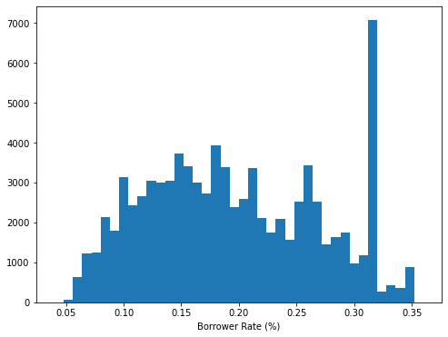

```python
# histogram
plt.figure(figsize = [8,6])

# set color of the plots
base_color = sb.color_palette()[0]

binsize = 0.008
bins = np.arange(0.04, df_relevant.BorrowerRate.max()+binsize, binsize)

plt.hist(data = df_relevant, x = 'BorrowerRate', bins = bins, color = base_color)
plt.xlabel("Borrower Rate (%)");
```

### Distribution of Loan status

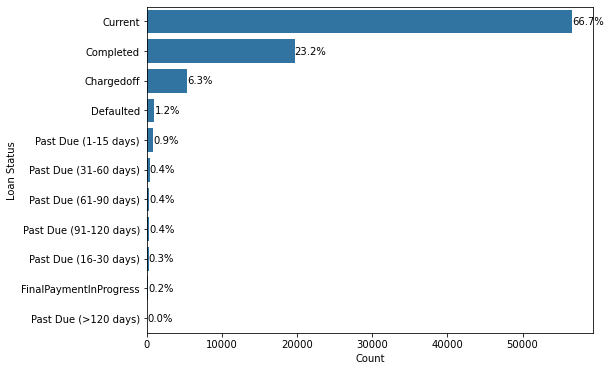

```python
# Relative Frequency of the different loan status

# size of figure
plt.figure(figsize = [8,6])

# order of Loan status from bad to good
status_order = df_relevant['LoanStatus'].value_counts().index

# standard horizontal bar chart
sb.countplot(data = df_relevant, y = 'LoanStatus', color = base_color, order = status_order)

# Returns the sum of all not-null values in the 'LoanStatus' column
n_loan_status = df_relevant['LoanStatus'].value_counts().sum()

# Count the frequency of unique values in the `LoanStatus` column
# By default, returns the decreasing order of the frequency.
loan_status_counts = df_relevant.LoanStatus.value_counts()


# Logic to print the proportion text on the bars
# use loop to place text one by one
for i in range (loan_status_counts.shape[0]):
    # Remember, `loan_status_counts` contains the frequency of unique values in the `LoanStatus` column in descreasing order
    count = loan_status_counts[i]

    # Convert count into a percentage, and then into a string
    pct_string = '{:0.1f}%'.format(100*count/n_loan_status)

    # Print the string value on the bar
    plt.text(count+1, i, pct_string, va='center', color = 'black')
plt.ylabel('Loan Status')
plt.xlabel('Count');
```

### Distribution of Prosper Rating

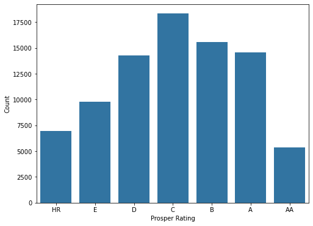

```python
# Convert the "PropserRating" column from a plain object type into an ordered categorical type
rating_order = ['HR', 'E', 'D', 'C', 'B', 'A', 'AA']
plot_rating_order = pd.api.types.CategoricalDtype(ordered = True, categories = rating_order)
df_relevant['ProsperRating'] = df_relevant['ProsperRating'].astype(plot_rating_order)

# size of figure
plt.figure(figsize = [8,6])

# Prosper ratings in ascending order, with AA as the highest rating and lowest risk
sb.countplot(data = df_relevant, x = 'ProsperRating', color = base_color)
plt.ylabel('Count')
plt.xlabel('Prosper Rating');
```

##### Observation

> *It can be observed that most prosper loans have a Prosper Rating C, and the lowest number of propser loans having a Prosper Rating of AA with the lowest risk*

### Distribution of Prosper Score

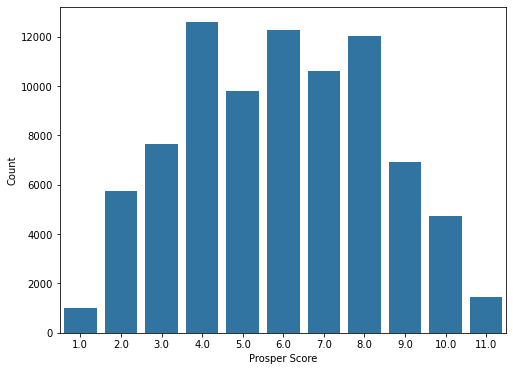

```python
# size of figure
plt.figure(figsize = [8,6])

sb.countplot(data = df_relevant, x = 'ProsperScore', color = base_color)
plt.ylabel('Count')
plt.xlabel('Prosper Score');
```

##### Observation

> *It can be observed that the distribution of Prosper Score has a bell-shaped distribution with spikes at Propser Score 4.0, 6.0, and 8.0*

### Distribution of Debt-to-Income ratio

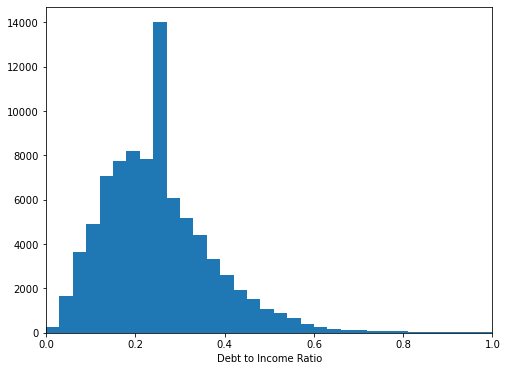

```python
# size of figure
plt.figure(figsize = [8,6])

# histogram bin size
binsize = 0.03
bins = np.arange(0, df_relevant.DebtToIncomeRatio.max()+binsize, binsize)

plt.hist(data = df_relevant, x = 'DebtToIncomeRatio', bins = bins)
plt.xlabel("Debt to Income Ratio")
plt.xlim(0,1);
```

##### Observation

> *Debt-to-income ratio compares how much you owe each month to how much you earn. It can be observed form the histogram baove that most borrowers have a debt-to-income ratio of 0.25.*

### Distribution of Listing Category

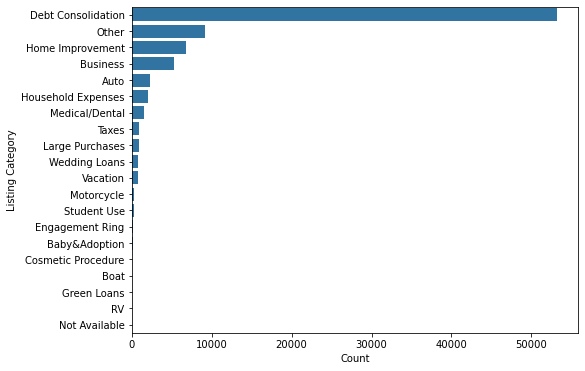

```python
# size of figure
plt.figure(figsize = [8, 6])

# select color of plot
base_color = sb.color_palette()[0]

# get count in descending order and assign index value to a variable
status_order = df_relevant.ListingCategory.value_counts().index

sb.countplot(data = df_relevant, y = 'ListingCategory', color = base_color, order = status_order)
plt.ylabel('Listing Category')
plt.xlabel('Count');
```

#### Observation

> *The Listing Category indicates the loan category that borrowers selected when posting their listing. It can be seen that the majority of borrowers applied for prosper loans to pay off other liabilities and consumer debts.*

### Distribution of Loan Original Amount

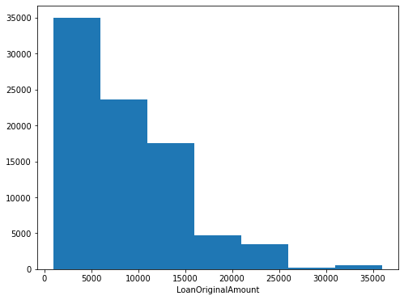

```python
# size of figure
plt.figure(figsize = [8,6])

binsize = 5000
bins = np.arange(1000, df_relevant.LoanOriginalAmount.max()+binsize, binsize)

plt.hist(data = df_relevant, x = 'LoanOriginalAmount', bins = bins, color = base_color)
plt.xlabel("LoanOriginalAmount");
```

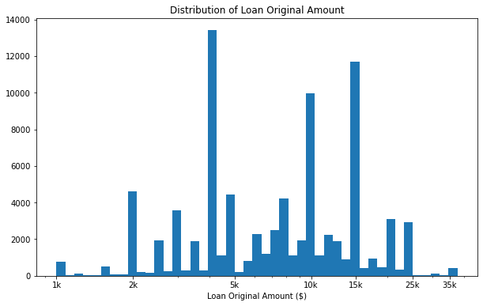

```python
# theres a long tail in the distribution, so let's put it on a log scale instead
plt.figure(figsize = [10,6])

# logarithmic bin size
log_binsize = 0.035
bins = 10 ** np.arange(3, np.log10(df_relevant.LoanOriginalAmount.max())+log_binsize, log_binsize)

plt.hist(data = df_relevant, x = 'LoanOriginalAmount', bins = bins)
plt.xscale('log')
plt.xticks([1000, 2000, 5000, 10000, 15000, 25000, 35000], ['1k', '2k', '5k', '10k', '15k', '25k', '35k'])
plt.xlabel("Loan Original Amount ($)")
plt.title('Distribution of Loan Original Amount')
plt.show();
```

### Distribution of Loan Term

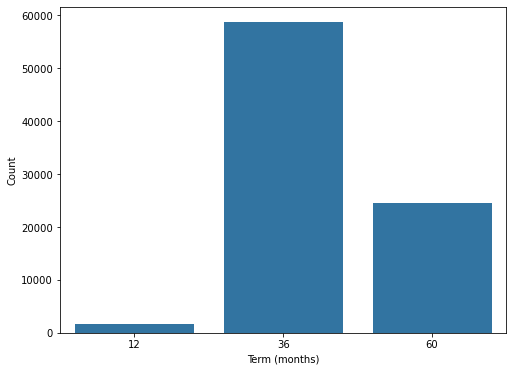

```python
# size of figure
plt.figure(figsize = [8,6])

sb.countplot(data = df_relevant, x = 'Term', color = base_color)
plt.ylabel('Count')
plt.xlabel('Term (months)');
```

#### Observation

> *It can be observed that most borrowers have a 3-year loan term to repay the loan whereas the lowest number of borrowers have a 1-year loan term.*

### Distribution of Income Range

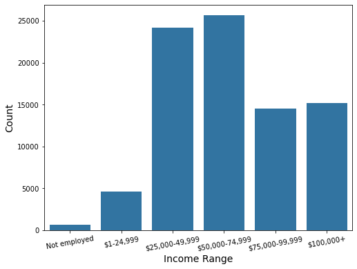

```python
# size of figure
plt.figure(figsize = [8,6])

# replace values with `$0` as `Not employed'
df_relevant.replace({'IncomeRange' : { '$0' : 'Not employed'}}, inplace = True)

# order income range in ascending order
income_order =['Not employed', '$1-24,999', '$25,000-49,999', '$50,000-74,999', '$75,000-99,999', '$100,000+']

sb.countplot(data = df_relevant, x = 'IncomeRange', color = base_color, order = income_order)
plt.ylabel('Count', fontsize=14)
plt.xlabel('Income Range', fontsize=14)
plt.xticks(rotation = 10);
```

#### Observation

> *It can be observed that most borrowers have a yearly income between 50,000 and 74,900. Surprisingly, the lowest number of Borrowers are unemployed.*

### Distribution of Borrower State

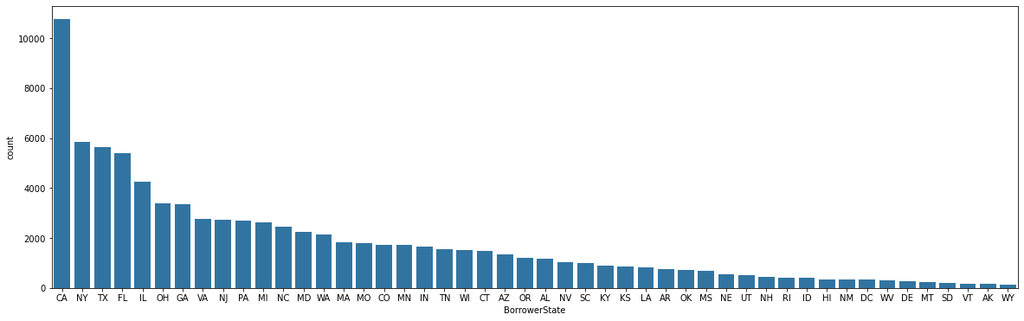

```python
# size of figure
plt.figure(figsize = [20,6])

# plot
base_color = sb.color_palette()[0]
state_order = df_relevant.BorrowerState.value_counts().index
sb.countplot(data = df_relevant, x = 'BorrowerState', order = state_order, color = base_color);
```

#### Observation

> *The majority of borrowers are from California, with New York having the second highest number of borrowers whereas Wyoming had the lowest number of borrowers. This could be an indication of higher cost of living in California and New York compared to other states*.

#### Discussion of Univariate Exploration

> The loan original amount variable took on a large range of values, so I looked at the data using a log transform. Under the transformation, the data looked multimodal with three peaks at 4K, 10K, and 15K.

> When investigating the Prosper Rating and Score, a number of points were missing. These variables were very important for the analyis as they were factors used in the loan approval prcess. So I had to drop the null values to analyze the points relevant for the project. Also, some other cleaning adjustment were re-ordering nominal variables such as Prosper Rating

## Bivariate Exploration

To start off with, I want to look at the pairwise correlations present between features in the data.

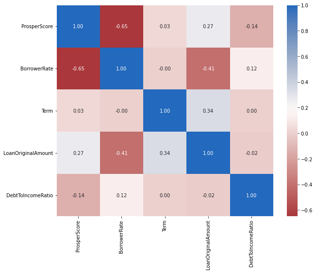

```python
# Correlation heatmap between the numerical variables
numeric_vars = ['ProsperScore', 'BorrowerRate', 'Term', 'LoanOriginalAmount', 'DebtToIncomeRatio']

# correlation plot
plt.figure(figsize = [10,8])

sb.heatmap(df_relevant[numeric_vars].corr(), cmap = 'vlag_r', annot = True, fmt = '.2f')
plt.xticks(rotation = 90);
```

### Borrower Rate vs Loan Status

Since there are a lot of categories in the `LoanStatus` column, especially `Past Due` having multiple deliquency buckets, the `Past Due` deliquency buckets will be aggregated as one `Past Due` category and a column `loan_status_aggr` created to house the aggregated loan status

```python
# aggregate the multiple `Past Due` deliquency buckets into a single 'Past Due' category
df_relevant['loan_status_aggr'] = df_relevant['LoanStatus'].apply(lambda x: x if 'Past Due' not in x else 'Past Due')

# Convert the "LoanStatus" column from a plain object type into an ordered categorical type
loan_status_group = ['Chargedoff', 'Defaulted', 'Past Due', 'Current', 'FinalPaymentInProgress', 'Completed']
loan_status_order = pd.api.types.CategoricalDtype(ordered = True, categories = loan_status_group)
df_relevant['loan_status_aggr'] = df_relevant['loan_status_aggr'].astype(loan_status_order)
```

I'll write a function to create three different plots (boxplot, violin plot, and combined box and violin plot). The choice of plots have been assigned to the name of the plot and can be selected as follows;

**`box_violin_plots(kind, df, x, y, xlabel, ylabel)`**

Parameters:

**kind:** the name of the plot you want displayed

- box --> boxplot
- violin --> violin plot
- box_violin --> combined box and violin plot

**df:** DataFrame, array, or list of arrays, optional

**x, y:** names of variables in data or vector data

**xlabel, ylabel:** axis names

The combined box and violin plot is included because box plot only shows summary statistics whereas the violin plot shows the full distribution of the data depicting both summary statistics and the density of each variable. Hence, sometimes the violin plot can be more informative than the boxplot.

```python
# function to display boxplot, violin plot, and a combined box and violin plot
def box_violin_plots(kind, df, x, y, xlabel, ylabel):
    base_color = sb.color_palette()[0]
    if kind == 'box':
        plt.figure(figsize = [15,7])
        sb.boxplot(data = df, x = x, y= y, color = base_color)
        plt.ylabel(ylabel, fontsize=12)
        plt.xlabel(xlabel, fontsize=12)
    elif kind == 'violin':
        plt.figure(figsize = [15,7])
        sb.violinplot(data = df, x = x, y= y, color = base_color)
        plt.ylabel(ylabel, fontsize=12)
        plt.xlabel(xlabel, fontsize=12)
    elif kind == 'box_violin':
        fig, ax = plt.subplots(nrows = 2, figsize = [13, 10], sharex= True, sharey = True, constrained_layout = True)
        sb.boxplot(data = df, x = x, y= y, color = base_color, ax = ax[0])
        sb.violinplot(data = df, x = x, y= y, color = base_color, ax = ax[1])

        # Use Common Labels for both x and y axis
        ax[0].set_xlabel(""), ax[0].set_ylabel("")
        ax[1].set_xlabel(""), ax[1].set_ylabel("")
        fig.supxlabel(xlabel)
        fig.supylabel(ylabel)
    return
```

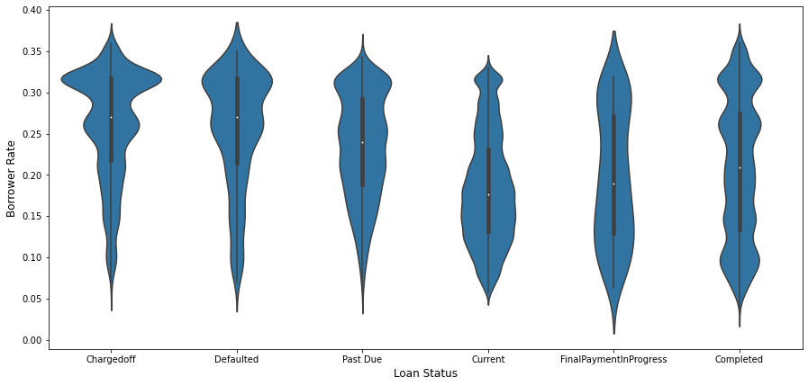

```python
# violin plot of Borrower Rate vs Loan Status
box_violin_plots('violin', df_relevant, 'loan_status_aggr', 'BorrowerRate', 'Loan Status', 'Borrower Rate')
```

#### Observation

> *As expected there is a relationship between Borrower Rate and Loan Status. It can be observed that borrowers that are delinquent have higher borrower rates with the bulk of data in the deliquent status around the 0.32% borrowers rate. Being delinquent on payments could be an indication of higher interest rates.*

### Borrower Rate and Prosper Rating

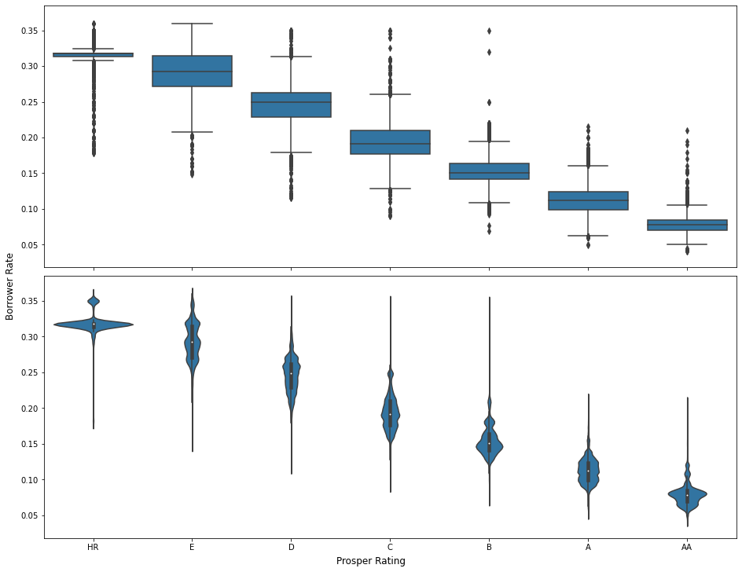

```python
# box and violin plots of Borrower Rate and Prosper Rating
box_violin_plots('box_violin', df_relevant, 'ProsperRating', 'BorrowerRate', 'Prosper Rating', 'Borrower Rate')
```

**Observation**

> *Not surprisngly, there is a negative relationship between Prosper Rating and Borrower Rate. Loans with higher Propser Ratings tend to have lower interest rates. It can also be observed from the violin plot that a huge distribution of loans with the lowest Prosper Rating "HR" have a high Borrower Rate of about 0.32%*

### Borrower Rate and Prosper Score

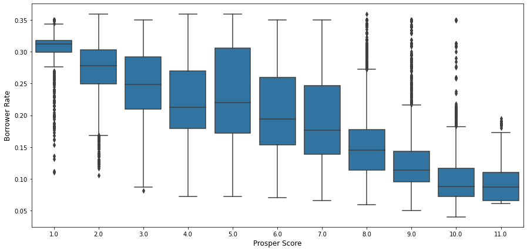

```python
# boxplot of Borrower Rate and Prosper Rating
box_violin_plots('box', df_relevant, 'ProsperScore', 'BorrowerRate', 'Prosper Score', 'Borrower Rate')
```

#### Observation

> *The same observation with Prosper Rating can be observed here as there is an inverse relationship between Prosper Score and Borrower Rate. Borrowers with higher Prosper Score tend to have lower Borrower Rate.*

### Relationship between Borrower Rate and variables: Income Range, IsBorrowerHomeowner, and Loan Term

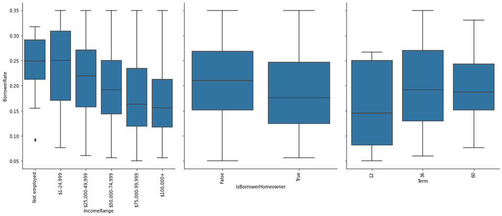

```python
# Convert the "IncomeRange" column from a plain object type into an ordered categorical type
plot_income_order = ['Not employed', '$1-24,999', '$25,000-49,999', '$50,000-74,999', '$75,000-99,999', '$100,000+']
plot_income_range_order = pd.api.types.CategoricalDtype(ordered = True, categories = plot_income_order)
df_relevant['IncomeRange'] = df_relevant['IncomeRange'].astype(plot_income_range_order)

# plot matrix of numeric features against categorical/ordinal features.
# use a 2000 sample since there are fewer plots and they're simpler in nature.
df_sample = df_relevant.sample(2000, replace=False)

#define boxgrid function
def boxgrid(x, y, **kwargs):
    base_color = sb.color_palette()[0]
    sb.boxplot(x, y, color = base_color)
    plt.xticks(rotation=90)

# plot
g = sb.PairGrid(data = df_sample, y_vars = ['BorrowerRate'], x_vars = ['IncomeRange','IsBorrowerHomeowner', 'Term'],
                height = 6, aspect = 0.9)
g.map(boxgrid)
plt.show();
```

#### Observation

> *Not surprising, it appears there is a negative relationship between Borrower rate and Income Range. The lower your Income the higher your Interest Rate, with unemployed people having the highest Borrower Rate.*

> *Likewise there is a relationship between homeowners and Borrower Rate. People that own homes tend to have lower interest rates unlike people without homes.*

### Loan Status vs Prosper Score

```python
# Boxplot showing the relationship between Loan Status and Prosper Score
box_violin_plots(0, df_relevant, 'loan_status_aggr', 'ProsperScore', 'Loan Status', 'Prosper Score')
```

[output not shown]

### Loan Status and Income Range

```python
# Convert the "IncomeRange" column from a plain object type into an ordered categorical type
plot_income_order = ['Not employed', '$1-24,999', '$25,000-49,999', '$50,000-74,999', '$75,000-99,999', '$100,000+']
plot_income_range_order = pd.api.types.CategoricalDtype(ordered = True, categories = plot_income_order)
df_relevant['IncomeRange'] = df_relevant['IncomeRange'].astype(plot_income_range_order)
```

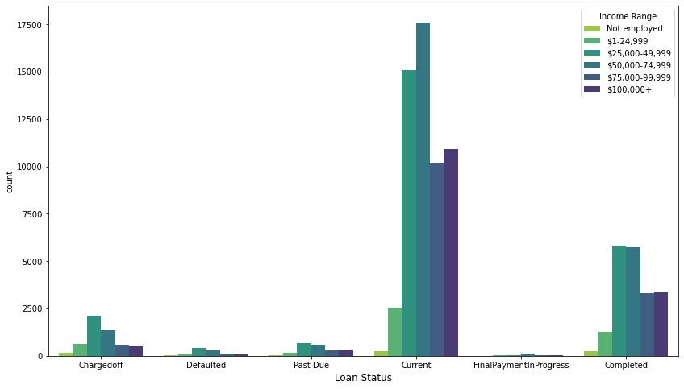

```python
# clustered bar chart
plt.figure(figsize = [14, 8])

sb.countplot(data = df_relevant, x = 'loan_status_aggr', hue = 'IncomeRange', palette = 'viridis_r')
plt.legend(title = 'Income Range')
plt.xlabel("Loan Status", fontsize=12);
```

#### Observation

> *Surprinsgly, unemployed people seem to have the lowest number across all loan status which could either be an indication that the unemployed are unlikely to be approved for a loan or the unemployed seldomly apply for a loan.*

> *It can also be observed that people within the income range of 25000 - 49999 are the most delinquent and also the most dutiful with completed loans status. This unusual observation could just be because the middle class are more likely to apply and are approved for a loan.*

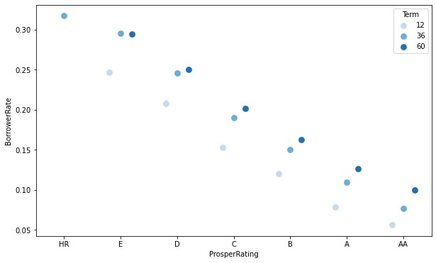

```python
plt.figure(figsize = [10, 6])

sb.pointplot(data = df_relevant, x = 'ProsperRating', y = 'BorrowerRate', hue = 'Term',
             palette = 'Blues', linestyles = '', dodge = 0.4)
```

### Borrower rate Time Series Plot

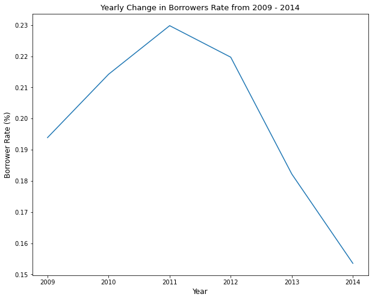

```python
# size of figure
plt.figure(figsize = [10,8])

# line chart
sb.lineplot(data = df_relevant, x = 'listing_year', y = 'BorrowerRate', ci = None)
plt.ylabel("Borrower Rate (%)", fontsize=12)
plt.xlabel('Year', fontsize=12)
plt.title("Yearly Change in Borrowers Rate from 2009 - 2014", fontsize=13);
```

#### Observation

> *The yearly change in Borrowers Rate shows that there was a significant increase in Borrowers Rate from 2009 with an all time high in 2011, followed by a decline in 2012, and then a steep decrease in the borrowers rate from 2012 till 2014. It will be worth investigating this change in Borrowers Rate.*

#### Discussion of Bivariate Exploration

> There is a negative relationship between Prosper Rating and Borrower Rate. This same inverse relationship was also observed when looking at the relationship between Borrower Rate and other variables (Prosper Score, Income Range, IsBorrowerHomeowner). All these variables could be used in determining the Borrower Rate for a Prosper Loan

## Multivariate Exploration

The main thing I want to explore in this part of the analysis is the relationship between three or more variables and their effect on borrowers rate

### Borrowers Rate by Prosper Score and Income Range

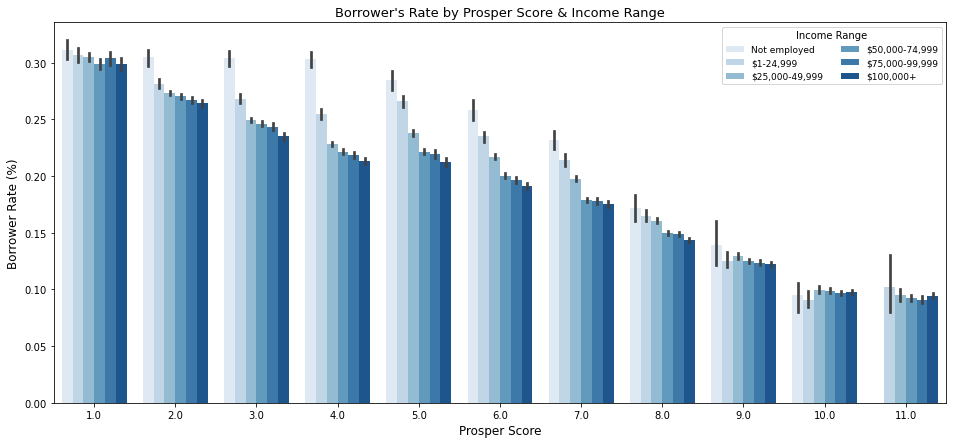

```python
# Clustered Bar Chart
plt.figure(figsize = [16,7])
ax = sb.barplot(data = df_relevant, x = 'ProsperScore', y = 'BorrowerRate', hue = 'IncomeRange', palette = 'Blues')
plt.ylabel("Borrower Rate (%)", fontsize=12)
plt.xlabel('Prosper Score', fontsize=12)
ax.legend(loc = 1, ncol = 2, title = 'Income Range', fontsize = 9) # re-arrange legend to remove overlapping
plt.title("Borrower's Rate by Prosper Score & Income Range", fontsize=13)
plt.show();
```

#### Observation

> *The higher the prosper score, the lower the borrowers rate as can be seem across all income ranges. Regardless of an individuals income, borrowers with lower propser score tend to have higher interest rates.*

> *An interesting observation is the minimal difference in borrowers rate for very low prosper scores and very high prosper scores. It can be seen that for propser scores 8 -11, there is a very small difference between the borrowers rate. This observation can also be observed for very low prosper score where the borrowers rate have very small difference across all income ranges. However for Propser scores within 3 and 7, theres seems to be a significant difference between unemployed and the other Income ranges. It seems Income Range is a huge factor with people that fall within prosper scores of 3-7.*

### Borrower Rate by Prosper Rating and Income Range

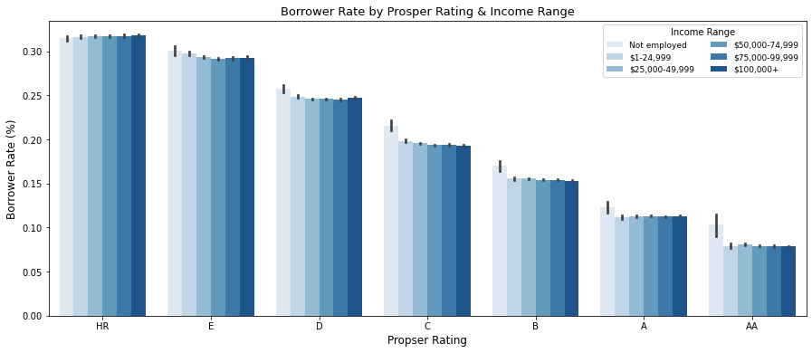

```python
plt.figure(figsize = [15,6])
ax = sb.barplot(data = df_relevant, x = 'ProsperRating', y = 'BorrowerRate', hue = 'IncomeRange', palette = 'Blues')
plt.ylabel("Borrower Rate (%)", fontsize=12)
plt.xlabel('Propser Rating', fontsize=12)
ax.legend(loc = 1, ncol = 2, title = 'Income Range', fontsize = 9) # re-arrange legend to remove overlapping
plt.title("Borrower Rate by Prosper Rating & Income Range", fontsize=13)
plt.show();
```

### Borrowers rate Time Series Plot for Homeowners and Non-Homeowners

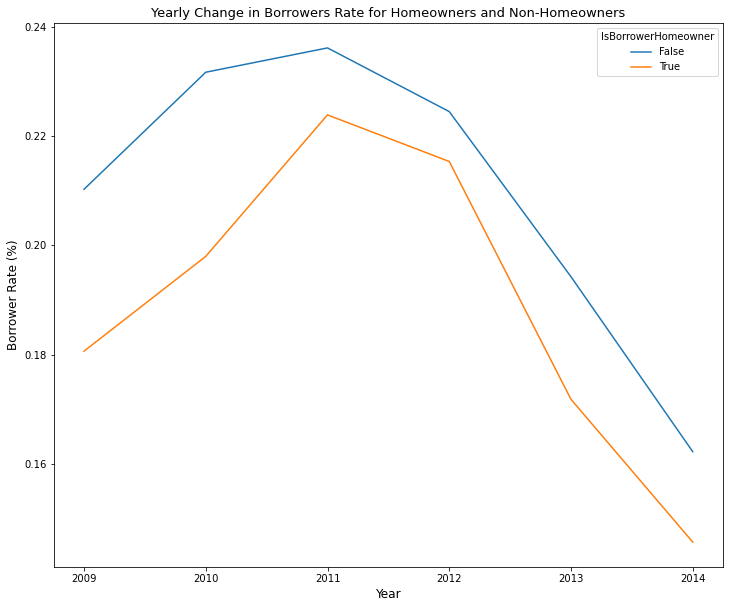

```python
# plots the lineplot to analyze homeowner's and non-homeowner's rate over years
plt.figure(figsize=(12,10))
sb.lineplot(data=df_relevant, x='listing_year', y='BorrowerRate', hue='IsBorrowerHomeowner',ci=None)
plt.ylabel("Borrower Rate (%)", fontsize=12)
plt.xlabel('Year', fontsize=12)
plt.title("Yearly Change in Borrowers Rate for Homeowners and Non-Homeowners", fontsize=13);
```

#### Observation

> *When comparing the yearly change in borrowers rates of home owners, it comes as no surprise that the borrowers rate for homeowners has always been lower than people who do not own homes. The difference in borrowers rate from 2009 to 2010 was significant, however, this difference in borrowers rate declined from 2011 to 2014, with homeowners always getting lower rates*

### Borrower Rate by Prosper rating and Loan terms

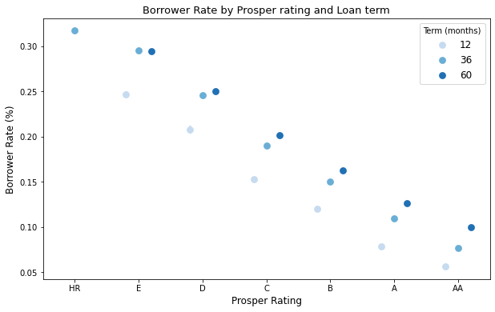

```python
plt.figure(figsize = [10, 6])

sb.pointplot(data = df_relevant, x = 'ProsperRating', y = 'BorrowerRate', hue = 'Term',
             palette = 'Blues', linestyles = '', dodge = 0.4)
plt.legend(title = 'Term (months)', fontsize = 12)
plt.ylabel("Borrower Rate (%)", fontsize=12)
plt.xlabel('Prosper Rating', fontsize=12)
plt.title("Borrower Rate by Prosper rating and Loan term", fontsize=13)
plt.show();
```

#### Observations

> *With the exception of prosper ratings HR and E, it can be observed that with loans of the same prosper rating, borrowers rate is directly proportional to loan term. It can be seen that from prosper rating D to AA, loans with the same proper rating have a higher borrowers rate as loan term increases.*

> *Hence, for borrowers with the same prosper rating, loans with a longer pay off term usually have higher borrowers rate.*

### Borrower Rate by Prosper rating and Loan Status

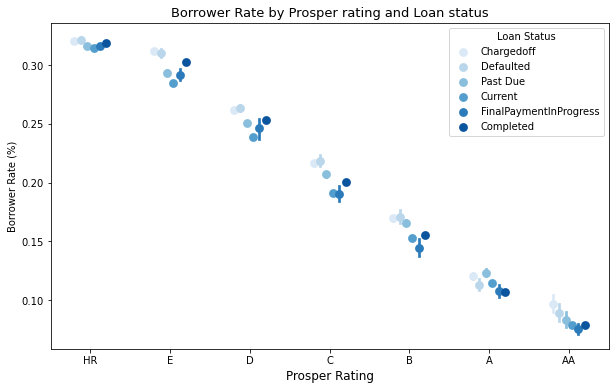

```python
plt.figure(figsize = [10, 6])
sb.pointplot(data = df_relevant, x = 'ProsperRating', y = 'BorrowerRate', hue = 'loan_status_aggr',
             palette = 'Blues', linestyles = '', dodge = 0.4)
plt.legend(title = 'Loan Status', fontsize = 10)
plt.ylabel("Borrower Rate (%)", fontsize=10)
plt.xlabel('Prosper Rating', fontsize=12)
plt.title("Borrower Rate by Prosper rating and Loan status", fontsize=13)
plt.show();
```

#### Observations

> *With the exception of prosper rating A, it can be seen that borrowers that are severely delinquent (chargedoff, defaulted) on loan payments usually have higher borrowers rates when compared to other loan status.*

### Borrower Rate by Prosper Score and Loan Status

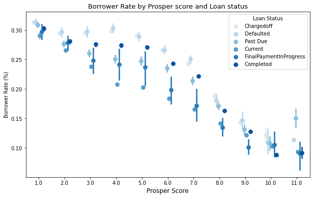

```python
plt.figure(figsize = [10, 6])
sb.pointplot(data = df_relevant, x = 'ProsperScore', y = 'BorrowerRate', hue = 'loan_status_aggr',
             palette = 'Blues', linestyles = '', dodge = 0.4)
plt.legend(title = 'Loan Status', fontsize = 10)
plt.ylabel("Borrower Rate (%)", fontsize=10)
plt.xlabel('Prosper Score', fontsize=12)
plt.title("Borrower Rate by Prosper score and Loan status", fontsize=13)
plt.show();
```

### Loan Status by Loan Original Amount and Is Borrower Homeowner

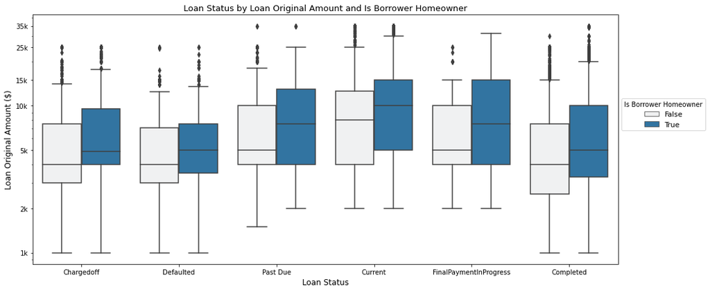

```python
plt.figure(figsize = [16,7])

# # logarithmic bin size
# log_binsize = 0.035
# bins = 10 ** np.arange(3, np.log10(df_relevant.LoanOriginalAmount.max())+log_binsize, log_binsize)

# plot
sb.boxplot(data = df_relevant, x = 'loan_status_aggr', y = 'LoanOriginalAmount', hue = 'IsBorrowerHomeowner', color = base_color)
plt.yscale('log')
plt.yticks([1000, 2000, 5000, 10000, 15000, 25000, 35000], ['1k', '2k', '5k', '10k', '15k', '25k', '35k'])

plt.legend(title = 'Is Borrower Homeowner', fontsize = 11, loc = 6, bbox_to_anchor = (1.0, 0.6)) # legend to right of figure
plt.ylabel("Loan Original Amount ($)", fontsize=12)
plt.xlabel('Loan Status', fontsize=12)
plt.title("Loan Status by Loan Original Amount and Is Borrower Homeowner", fontsize=13)
plt.show();
```

#### Observation

> *Generally, homeowners tend to get higher loan amounts as opposed to people who do not own a home. It can be seen that for every loan status, the median loanOriginalAmount for homeowners are higher than that of non-homeowners. Most non-homeowners tend to get smaller loans around 5k with the exception of non-homeowners in the Current status. It can also be seen that the original loan amount of homeowners for each loan status seem to have much greater variability than for non-homeowners.*

## Conclusions

> - Regardless of an individuals income, borrowers with lower propser score tend to have higher interest rates. So income might only be a determinant in borrowers rate, when there is no obvious difference in prosper score.
> - It can be observed that loans with the same proper ratings usually have a higher borrowers rate as loan term increases. It is evident that loan term is a major determinant of borrower rate, as there is a significant decrease in borrower rate with shorter loan terms
> - For all prosper ratings with the exception of prosper rating A, it can be seen that borrowers that are severely delinquent (chargedoff, defaulted) on loan payments usually have higher borrowers rates.
> - It can also be seen that with the mid-range prosper scores, borrowers that are delinquent (chargedoff, defaulted, Past Due) on loan payments usually have significantly higher borrowers rates than borrowers with the higher prosper scores._
> - When Income is considered, there seems to be minimal difference in borrowers rate for lower interest ratings like HR, E & D. But when observed from the mid prosper rating (C) to the highest prosper rating (AA), there is a significant difference in borrowers rate for unemployed people when compared to employed people.
> - Unlike 2009 and 2010, there seem to be a significant decrease in borrower rate between homeowners and non-homeowners from 2011.